# McKinsey

Neilson

## Packages

```r
pacman::p_load(tidyverse, caret, modelr, plotROC, arules, recipes)
# setwd("~/Projects/McKinsey")
```

## Read in data

```r
train <- read.csv('train.csv')
dim(train)
```

```
## [1] 79853    13
```

```r
summary(train)
```

```
##        id         perc_premium_paid_by_cash_credit  age_in_days
##  Min.   :     2   Min.   :0.0000                   Min.   : 7670
##  1st Qu.: 28640   1st Qu.:0.0340                   1st Qu.:14974
##  Median : 57262   Median :0.1670                   Median :18625
##  Mean   : 57167   Mean   :0.3143                   Mean   :18847
##  3rd Qu.: 85632   3rd Qu.:0.5380                   3rd Qu.:22636
##  Max.   :114076   Max.   :1.0000                   Max.   :37602
##
##      Income         Count_3.6_months_late Count_6.12_months_late
##  Min.   :   24030   Min.   : 0.0000       Min.   : 0.00000
##  1st Qu.:  108010   1st Qu.: 0.0000       1st Qu.: 0.00000
##  Median :  166560   Median : 0.0000       Median : 0.00000
##  Mean   :  208847   Mean   : 0.2487       Mean   : 0.07819
##  3rd Qu.:  252090   3rd Qu.: 0.0000       3rd Qu.: 0.00000
##  Max.   :90262600   Max.   :13.0000       Max.   :17.00000
##                     NA's   :97            NA's   :97
##  Count_more_than_12_months_late application_underwriting_score
##  Min.   : 0.00000               Min.   :91.90
##  1st Qu.: 0.00000               1st Qu.:98.81
##  Median : 0.00000               Median :99.21
##  Mean   : 0.06001               Mean   :99.07
##  3rd Qu.: 0.00000               3rd Qu.:99.54
##  Max.   :11.00000               Max.   :99.89
##  NA's   :97                     NA's   :2974
##  no_of_premiums_paid sourcing_channel residence_area_type    premium
##  Min.   : 2.00       A:43134          Rural:31670         Min.   : 1200
##  1st Qu.: 7.00       B:16512          Urban:48183         1st Qu.: 5400
##  Median :10.00       C:12039                              Median : 7500
##  Mean   :10.86       D: 7559                              Mean   :10925
##  3rd Qu.:14.00       E:  609                              3rd Qu.:13800
##  Max.   :60.00                                            Max.   :60000
##
##     renewal
##  Min.   :0.0000
##  1st Qu.:1.0000
##  Median :1.0000
##  Mean   :0.9374
##  3rd Qu.:1.0000
##  Max.   :1.0000
##
```

```r
trainCC <- train[complete.cases(train),]
dim(trainCC)
```

```
## [1] 76855    13
```

```r
colnames(trainCC)
```

```
##  [1] "id"                               "perc_premium_paid_by_cash_credit"
##  [3] "age_in_days"                      "Income"
##  [5] "Count_3.6_months_late"            "Count_6.12_months_late"
##  [7] "Count_more_than_12_months_late"   "application_underwriting_score"
##  [9] "no_of_premiums_paid"              "sourcing_channel"
## [11] "residence_area_type"              "premium"
## [13] "renewal"
```

## Logistic Reg

```r
lr1 <- glm(renewal ~ ., data = trainCC, family = 'binomial')
summary(lr1)
```

```
##
## Call:
## glm(formula = renewal ~ ., family = "binomial", data = trainCC)
##
## Deviance Residuals:
##     Min       1Q   Median       3Q      Max
## -3.3305   0.1830   0.2313   0.3312   4.3247
##
## Coefficients:
##                                    Estimate Std. Error z value Pr(>|z|)
## (Intercept)                      -1.443e+01  2.034e+00  -7.093 1.31e-12
## id                               -1.157e-06  5.014e-07  -2.307  0.02104
## perc_premium_paid_by_cash_credit -1.820e+00  5.018e-02 -36.270  < 2e-16
## age_in_days                       4.566e-05  3.793e-06  12.037  < 2e-16
## Income                            2.506e-07  1.560e-07   1.606  0.10821
## Count_3.6_months_late            -4.258e-01  1.582e-02 -26.920  < 2e-16
## Count_6.12_months_late           -7.274e-01  2.565e-02 -28.363  < 2e-16
## Count_more_than_12_months_late   -6.254e-01  3.335e-02 -18.752  < 2e-16
## application_underwriting_score    1.805e-01  2.039e-02   8.855  < 2e-16
## no_of_premiums_paid              -2.804e-02  3.619e-03  -7.748 9.31e-15
## sourcing_channelB                -1.537e-02  4.321e-02  -0.356  0.72209
## sourcing_channelC                -6.165e-02  4.638e-02  -1.329  0.18379
## sourcing_channelD                -1.706e-01  5.343e-02  -3.192  0.00141
## sourcing_channelE                -1.541e-01  1.708e-01  -0.902  0.36694
## residence_area_typeUrban          9.041e-03  3.363e-02   0.269  0.78808
## premium                           3.415e-06  2.708e-06   1.261  0.20724
##
## (Intercept)                      ***
## id                               *
## perc_premium_paid_by_cash_credit ***
## age_in_days                      ***
## Income
## Count_3.6_months_late            ***
## Count_6.12_months_late           ***
## Count_more_than_12_months_late   ***
## application_underwriting_score   ***
## no_of_premiums_paid              ***
## sourcing_channelB
## sourcing_channelC
## sourcing_channelD                **
## sourcing_channelE
## residence_area_typeUrban
## premium
## ---
## Signif. codes:  0 '***' 0.001 '**' 0.01 '*' 0.05 '.' 0.1 ' ' 1
##
## (Dispersion parameter for binomial family taken to be 1)
##
##     Null deviance: 35809  on 76854  degrees of freedom
## Residual deviance: 28524  on 76839  degrees of freedom
## AIC: 28556
##
## Number of Fisher Scoring iterations: 6
```

variables that don’t matter or VIF issues

- income
- most of the sourcing channels, except D (D is sig)
- residence area type
- premium

income + premium should matter, maybe VIF?? or need some kind of combination term

```r
varImp(lr1)
```

```
##                                     Overall
## id                                2.3071768
## perc_premium_paid_by_cash_credit 36.2697558
## age_in_days                      12.0372237
## Income                            1.6062944
## Count_3.6_months_late            26.9198756
## Count_6.12_months_late           28.3633654
## Count_more_than_12_months_late   18.7519314
## application_underwriting_score    8.8554386
## no_of_premiums_paid               7.7483972
## sourcing_channelB                 0.3556636
## sourcing_channelC                 1.3291628
## sourcing_channelD                 3.1919399
## sourcing_channelE                 0.9022158
## residence_area_typeUrban          0.2688080
## premium                           1.2611921
```

## ROC , AUC simplest model

```r
lr1pred <- predict(lr1, trainCC, type = 'resp')
head(lr1pred)
```

```
##         1         2         3         4         5         6
## 0.9414003 0.9834927 0.1982772 0.9818793 0.9897420 0.9051843
```

```r
trainCC$pred <- lr1pred
trainCC$predBinary <- as.integer(ifelse(trainCC$pred >= .90, 1, 0)) ## increased to up sensit
head(trainCC)
```

```
##       id perc_premium_paid_by_cash_credit age_in_days Income
## 1 110936                            0.429       12058 355060
## 2  41492                            0.010       21546 315150
## 3  31300                            0.917       17531  84140
## 4  19415                            0.049       15341 250510
## 5  99379                            0.052       31400 198680
## 6  59951                            0.540       17527 282080
##   Count_3.6_months_late Count_6.12_months_late
## 1                     0                      0
## 2                     0                      0
## 3                     2                      3
## 4                     0                      0
## 5                     0                      0
## 6                     2                      0
##   Count_more_than_12_months_late application_underwriting_score
```

[output cut: 20 more lines]

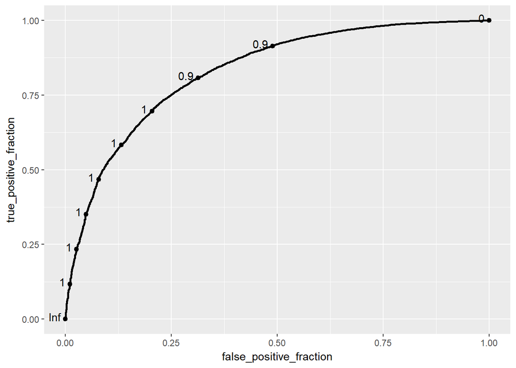

```r
simplest <- ggplot(trainCC, aes(d=renewal, m = pred))+geom_roc()
simplest
```

interactive version, visible after html rendering

```r
cat(
  export_interactive_roc(simplest,
                         prefix = 'a')
)
```

not working

```r
confusionMatrix(factor(trainCC$predBinary), factor(trainCC$renewal), pos='1')
```

```
## Confusion Matrix and Statistics
##
##           Reference
## Prediction     0     1
##          0  2724  8262
##          1  2056 63813
##
##                Accuracy : 0.8657
##                  95% CI : (0.8633, 0.8682)
##     No Information Rate : 0.9378
##     P-Value [Acc > NIR] : 1
##
##                   Kappa : 0.2834
##  Mcnemar's Test P-Value : <2e-16
##
##             Sensitivity : 0.8854
##             Specificity : 0.5699
##          Pos Pred Value : 0.9688
##          Neg Pred Value : 0.2480
##              Prevalence : 0.9378
##          Detection Rate : 0.8303
##    Detection Prevalence : 0.8571
##       Balanced Accuracy : 0.7276
##
##        'Positive' Class : 1
##
```

```r
library(pROC)
auc <- roc(trainCC$renewal, lr1pred)
auc
```

```
##
## Call:
## roc.default(response = trainCC$renewal, predictor = lr1pred)
##
## Data: lr1pred in 4780 controls (trainCC$renewal 0) < 72075 cases (trainCC$renewal 1).
## Area under the curve: 0.8295
```

## Explore Variables closer

let’s look at correlations

```r
library(DataExplorer)
trainCC$binary <- as.logical(trainCC$renewal)
# create_report(trainCC[,c(2:13)])
create_report(trainCC[c(2:12,16)]) # y = 'binary', config <- list(
  "introduce" = list(),
  "plot_str" = list(
    "type" = "diagonal",
    "fontSize" = 35,
    "width" = 1000,
    "margin" = list("left" = 350, "right" = 250)
  ),
  "plot_histogram" = list(),
  "plot_bar" = list(),
  "plot_correlation" = list("use" = "pairwise.complete.obs"),
  "plot_boxplot" = list(),
  "plot_scatterplot" = list()
))
```

html output not shown

- univariate distributions show lots of right-skewed, could probably benefit from log transforms to get more gaussian, specifically
- income -application underwriting score (left skew)
- no of premiums paid
- premium
- correlations
- premiums paid in cash correlates w/delinquency
- new features
- any history of delinquency
- combination of income + premium, either explicityly as some kind of percentage, or as a multiplicative factor in the fit

## Fix and New features

lets do some log transforms

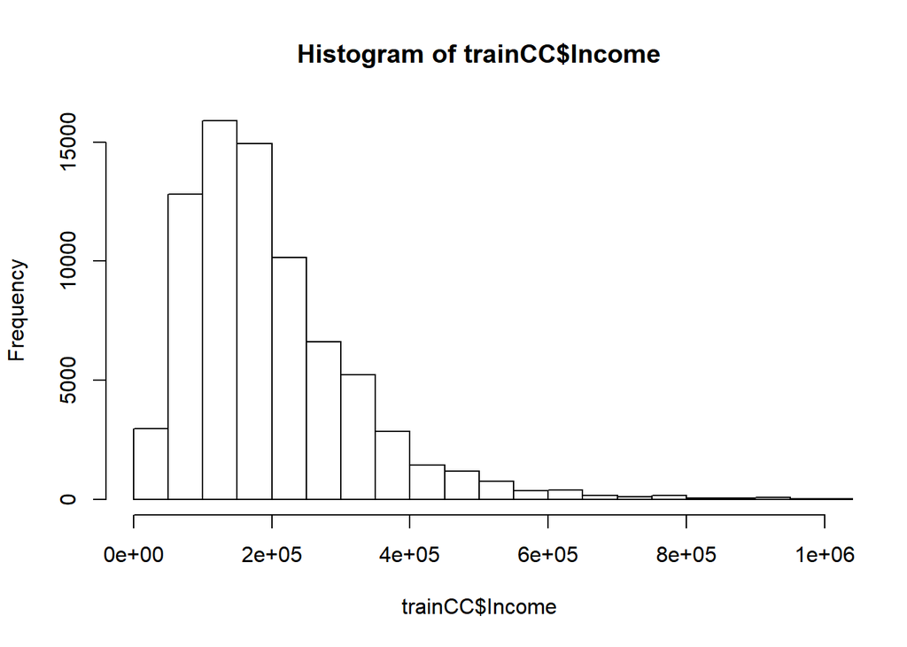

```r
hist(trainCC$Income, xlim = c(0,1e6), breaks = 1000)
```

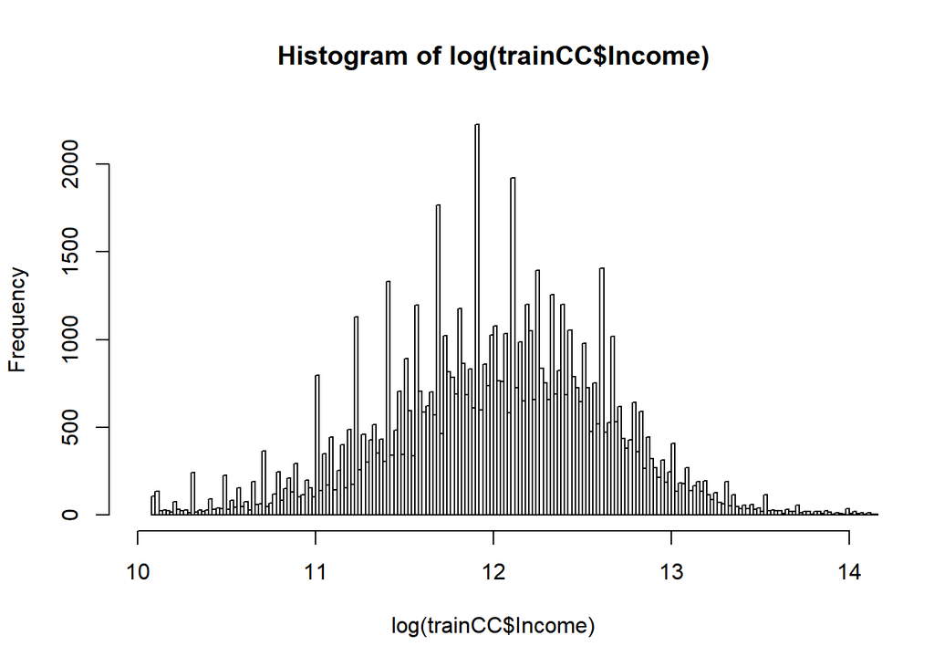

```r
hist(log(trainCC$Income), breaks=500, xlim=c(10,14))
```

```r
trainCC$lnIncome <- log(trainCC$Income)
range(trainCC$lnIncome)
```

```
## [1] 10.08706 17.80119
```

## Income categories

discretize function from arules

```r
summary(trainCC$Income)
```

```
##     Min.  1st Qu.   Median     Mean  3rd Qu.     Max.
##    24030   109805   168330   208839   254395 53821900
```

```r
table(arules::discretize(trainCC$Income, breaks = 4))
```

```
##
##   [2.4e+04,1.1e+05)  [1.1e+05,1.68e+05) [1.68e+05,2.54e+05)
##               19214               19213               19214
## [2.54e+05,5.38e+07]
##               19214
```

```r
incomeBins <- recipes::discretize(trainCC$Income, cuts = 4, labels = c('low', 'med', 'high', 'rich'), keep_na = FALSE, prefix="") # don't forget quotes in labels
class(incomeBins) # cool
```

```
## [1] "discretize"
```

```r
trainCC$incomeCat <- predict(incomeBins, trainCC$Income)
summary(trainCC$incomeCat)
```

```
##   low   med  high  rich
## 19214 19215 19212 19214
```

## Scale for preProcess

note, requires dataframe, cant use dollar sign index

```r
scaleIncome <- preProcess(trainCC['lnIncome'])
dim(trainCC['lnIncome'])
```

```
## [1] 76855     1
```

```r
trainCC$scaleLnIncome <- predict(scaleIncome,  trainCC['lnIncome'])
class(trainCC$scaleLnIncome)
```

```
## [1] "data.frame"
```

## Counts

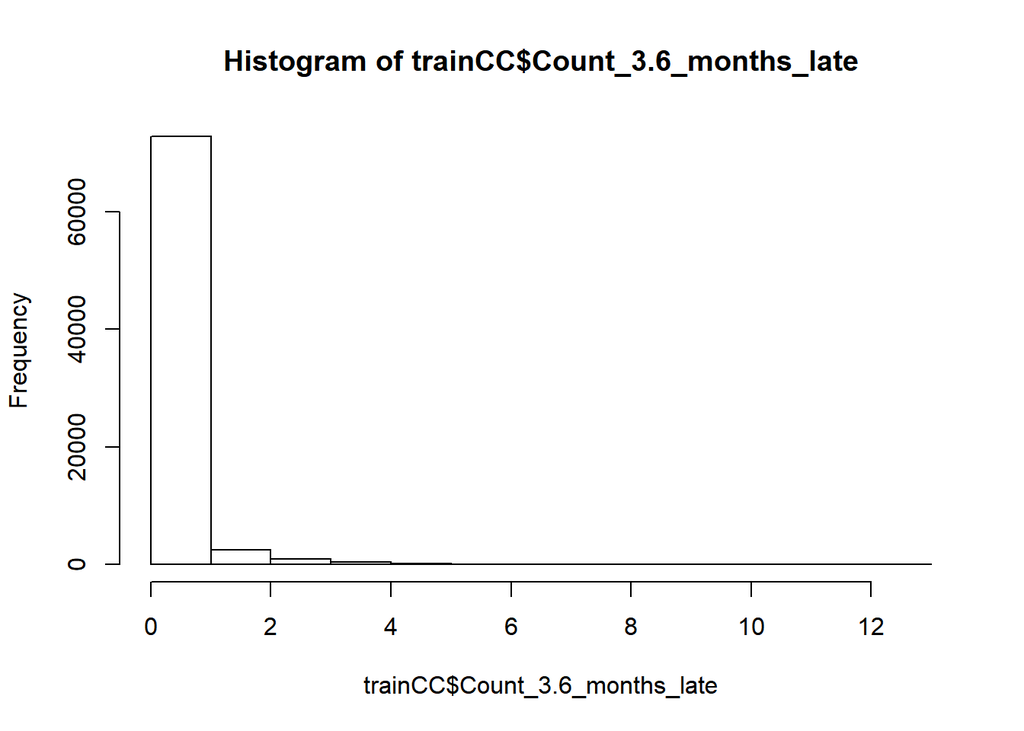

```r
hist(trainCC$Count_3.6_months_late)
```

weird

are they ever late?

```r
trainCC$everlate <- ifelse(trainCC$Count_3.6_months_late>0, 1,0)
summary(trainCC$everlate)
```

```
##    Min. 1st Qu.  Median    Mean 3rd Qu.    Max.
##  0.0000  0.0000  0.0000  0.1657  0.0000  1.0000
```

16%… cool, seems useable

sanity check, that category is enough to investigate

```r
summary(trainCC$Count_6.12_months_late) # ~8%
```

```
##     Min.  1st Qu.   Median     Mean  3rd Qu.     Max.
##  0.00000  0.00000  0.00000  0.07694  0.00000 17.00000
```

```r
summary(trainCC$Count_more_than_12_months_late) #~6%
```

```
##     Min.  1st Qu.   Median     Mean  3rd Qu.     Max.
##  0.00000  0.00000  0.00000  0.06115  0.00000 11.00000
```

```r
trainCC$verylate <- ifelse(trainCC$Count_6.12_months_late>0,1,0)
```

## Underwriting score

just going to scale ## doesn’t work doesnt work

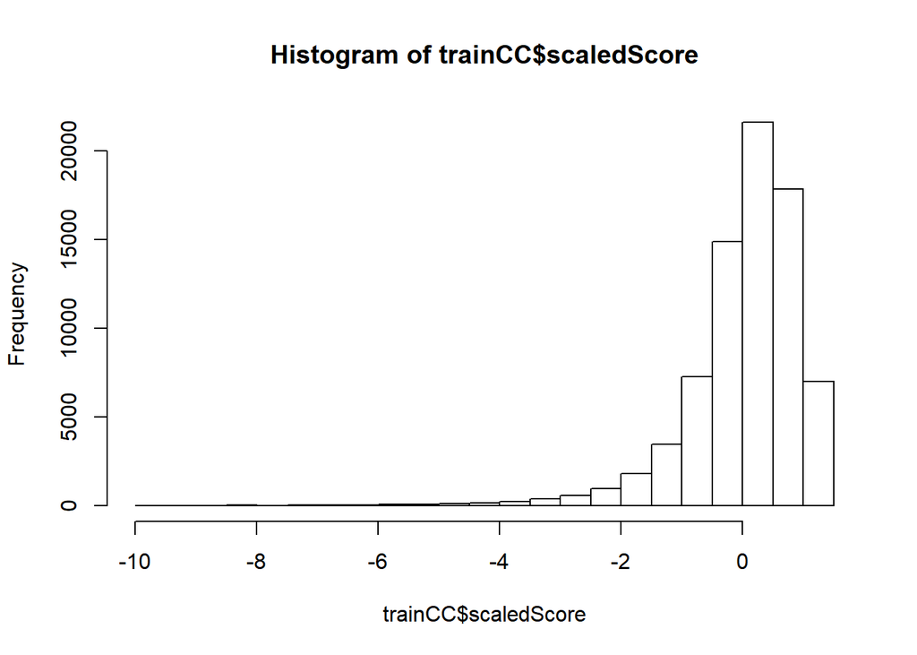

```r
trainCC$scaledScore <- scale(trainCC$application_underwriting_score)
hist(trainCC$scaledScore)
```

doesnt look any different

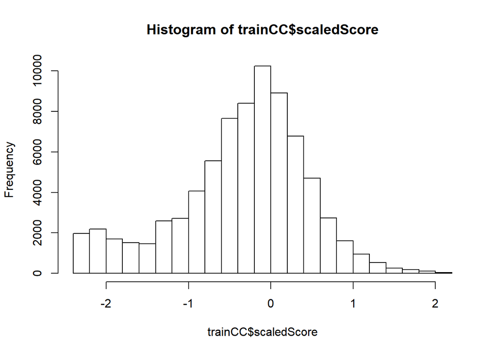

```r
trainCC$scaledScore <- log(100-trainCC$application_underwriting_score)
hist(trainCC$scaledScore)
```

better

## No premiums

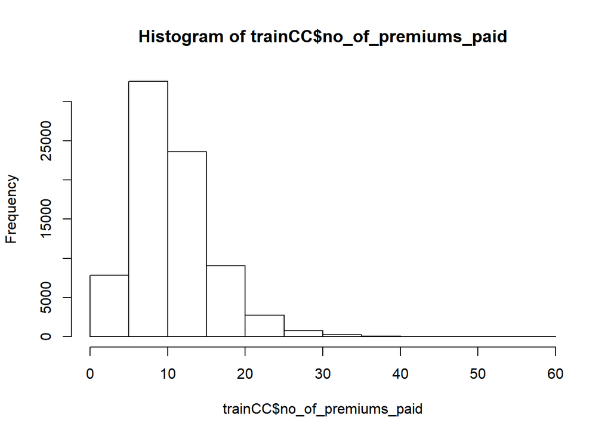

```r
hist(trainCC$no_of_premiums_paid)
```

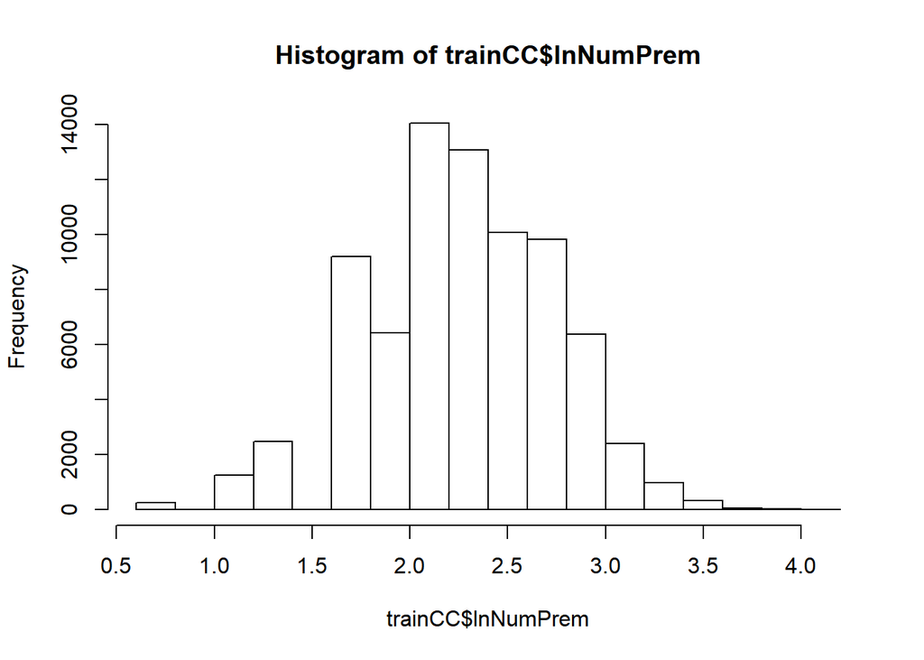

```r
trainCC$lnNumPrem <- log(trainCC$no_of_premiums_paid)
hist(trainCC$lnNumPrem)
```

## cash money

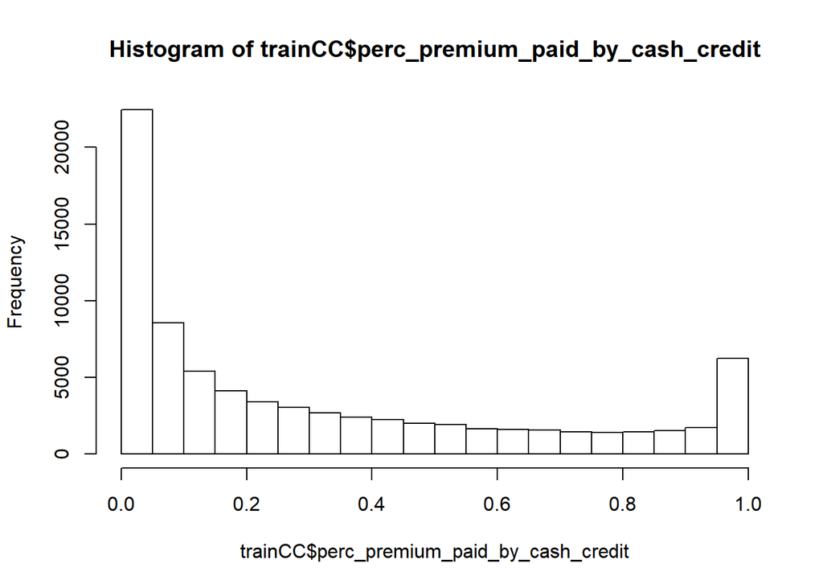

```r
hist(trainCC$perc_premium_paid_by_cash_credit)
```

what percent never use cash

```r
summary(trainCC$perc_premium_paid_by_cash_credit)
```

```
##    Min. 1st Qu.  Median    Mean 3rd Qu.    Max.
##  0.0000  0.0380  0.1740  0.3148  0.5345  1.0000
```

separate out extremes, cat variable

```r
trainCC$allCash <- ifelse(trainCC$perc_premium_paid_by_cash_credit == 0, 1,0)
trainCC$allCred <- ifelse(trainCC$perc_premium_paid_by_cash_credit == 1, 1,0)
# summary(trainCC[24:25])
```

discretize?

```r
# table(arules::discretize(trainCC$Income, breaks = 4))
table(arules::discretize(trainCC$perc_premium_paid_by_cash_credit, breaks=4))
```

```
##
##     [0,0.038) [0.038,0.174) [0.174,0.534)     [0.534,1]
##         19132         19280         19229         19214
```

first quartile pretty low sure let’s try

```r
cashBin <- recipes::discretize(trainCC$perc_premium_paid_by_cash_credit, cuts = 4, labels = c('low', 'med', 'high', 'wow'), keep_na = FALSE, prefix="") # don't forget quotes in labels

trainCC$cashBin <- predict(cashBin, trainCC$perc_premium_paid_by_cash_credit)
```

## source D

```r
trainCC$sourceD <- ifelse(trainCC$sourcing_channel=='D',1,0)
```

## premium over income

```r
trainCC$premiumPercent <- trainCC$premium / trainCC$Income
range(trainCC$premiumPercent)  # wow, 23%?!
```

```
## [1] 0.001114788 0.237203496
```

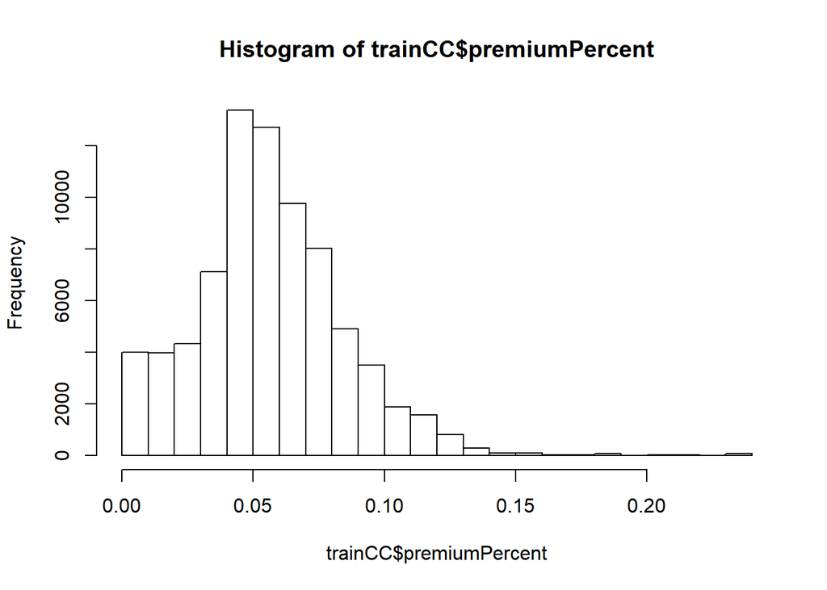

```r
hist(trainCC$premiumPercent)
```

## reshuffle

```r
colnames(trainCC)
```

```
##  [1] "id"                               "perc_premium_paid_by_cash_credit"
##  [3] "age_in_days"                      "Income"
##  [5] "Count_3.6_months_late"            "Count_6.12_months_late"
##  [7] "Count_more_than_12_months_late"   "application_underwriting_score"
##  [9] "no_of_premiums_paid"              "sourcing_channel"
## [11] "residence_area_type"              "premium"
## [13] "renewal"                          "pred"
## [15] "predBinary"                       "lnIncome"
## [17] "incomeCat"                        "scaleLnIncome"
## [19] "everlate"                         "verylate"
## [21] "scaledScore"                      "lnNumPrem"
## [23] "allCash"                          "allCred"
## [25] "cashBin"                          "sourceD"
## [27] "premiumPercent"
```

```r
modTrain <- trainCC %>%
  select(id,
         premium,
         age_in_days,
         lnNumPrem,
         scaledScore,
         perc_premium_paid_by_cash_credit,
         allCash, #allCred,

         cashBin,
         everlate,
         verylate,
         incomeCat, #scaleLnIncome,

         sourceD, # premiumPercent,


         renewal)
```

## new model

```r
lr2 <- glm(renewal ~ . -id, data=modTrain, family = 'binomial')
summary(lr2)
```

```
##
## Call:
## glm(formula = renewal ~ . - id, family = "binomial", data = modTrain)
##
## Deviance Residuals:
##     Min       1Q   Median       3Q      Max
## -3.1819   0.1683   0.2260   0.3345   1.7100
##
## Coefficients:
##                                    Estimate Std. Error z value Pr(>|z|)
## (Intercept)                       4.199e+00  1.391e-01  30.189  < 2e-16
## premium                          -4.631e-06  2.432e-06  -1.904 0.056937
## age_in_days                       3.927e-05  3.718e-06  10.563  < 2e-16
## lnNumPrem                        -3.446e-01  4.490e-02  -7.675 1.65e-14
## scaledScore                      -1.519e-01  2.649e-02  -5.735 9.73e-09
## perc_premium_paid_by_cash_credit -1.740e+00  1.431e-01 -12.163  < 2e-16
## allCash                          -5.964e-01  1.072e-01  -5.563 2.65e-08
## cashBinmed                       -2.229e-01  8.441e-02  -2.640 0.008286
## cashBinhigh                      -3.168e-01  9.095e-02  -3.484 0.000495
## cashBinwow                       -3.120e-01  1.374e-01  -2.271 0.023176
## everlate                         -1.035e+00  3.449e-02 -29.999  < 2e-16
## verylate                         -1.783e+00  4.361e-02 -40.874  < 2e-16
## incomeCatmed                      1.293e-01  4.413e-02   2.929 0.003398
## incomeCathigh                     3.378e-01  5.012e-02   6.740 1.58e-11
## incomeCatrich                     4.289e-01  6.487e-02   6.611 3.83e-11
## sourceD                          -1.704e-01  5.006e-02  -3.404 0.000664
##
## (Intercept)                      ***
## premium                          .
## age_in_days                      ***
## lnNumPrem                        ***
## scaledScore                      ***
## perc_premium_paid_by_cash_credit ***
## allCash                          ***
## cashBinmed                       **
## cashBinhigh                      ***
## cashBinwow                       *
## everlate                         ***
## verylate                         ***
## incomeCatmed                     **
## incomeCathigh                    ***
## incomeCatrich                    ***
## sourceD                          ***
## ---
## Signif. codes:  0 '***' 0.001 '**' 0.01 '*' 0.05 '.' 0.1 ' ' 1
##
## (Dispersion parameter for binomial family taken to be 1)
##
##     Null deviance: 35809  on 76854  degrees of freedom
## Residual deviance: 28609  on 76839  degrees of freedom
## AIC: 28641
##
## Number of Fisher Scoring iterations: 7
```

## ROC and AUC

```r
lr2pred <- predict(lr2, modTrain, type = 'resp')
# head(lr2pred)
modTrain$pred <- lr2pred
modTrain$predBinary <- as.integer(ifelse(trainCC$pred >= .9, 1, 0)) ## increased to up sensit
head(modTrain)
```

```
##       id premium age_in_days lnNumPrem scaledScore
## 1 110936    3300       12058  2.564949 -0.02020271
## 2  41492   18000       21546  3.044522 -2.20727491
## 3  31300    3300       17531  1.945910  0.27002714
## 4  19415    9600       15341  2.197225 -0.84397007
## 5  99379    9600       31400  2.484907 -2.04022083
## 6  59951   22200       17527  2.197225 -0.19845094
##   perc_premium_paid_by_cash_credit allCash cashBin everlate verylate
## 1                            0.429       0    high        0        0
## 2                            0.010       0     low        0        0
## 3                            0.917       0     wow        1        1
## 4                            0.049       0     med        0        0
## 5                            0.052       0     med        0        0
## 6                            0.540       0     wow        1        0
##   incomeCat sourceD renewal      pred predBinary
## 1      rich       0       1 0.9585984          1
## 2      rich       0       1 0.9906201          1
## 3       low       0       0 0.3625507          0
## 4      high       0       1 0.9846025          1
## 5      high       0       1 0.9923557          1
## 6      rich       0       1 0.9002635          1
```

```r
round2 <- ggplot(modTrain, aes(d=renewal, m = pred))+geom_roc()
round2
```

[output not shown]

```r
confusionMatrix(factor(modTrain$predBinary), factor(modTrain$renewal), pos='1')
```

```
## Confusion Matrix and Statistics
##
##           Reference
## Prediction     0     1
##          0  2724  8262
##          1  2056 63813
##
##                Accuracy : 0.8657
##                  95% CI : (0.8633, 0.8682)
##     No Information Rate : 0.9378
##     P-Value [Acc > NIR] : 1
##
##                   Kappa : 0.2834
##  Mcnemar's Test P-Value : <2e-16
##
##             Sensitivity : 0.8854
##             Specificity : 0.5699
##          Pos Pred Value : 0.9688
##          Neg Pred Value : 0.2480
##              Prevalence : 0.9378
##          Detection Rate : 0.8303
##    Detection Prevalence : 0.8571
##       Balanced Accuracy : 0.7276
##
##        'Positive' Class : 1
##
```

```r
library(pROC)
auc2 <- roc(modTrain$renewal, lr2pred)
auc2
```

```
##
## Call:
## roc.default(response = modTrain$renewal, predictor = lr2pred)
##
## Data: lr2pred in 4780 controls (modTrain$renewal 0) < 72075 cases (modTrain$renewal 1).
## Area under the curve: 0.8239
```

## preProcess all

```r
glimpse(modTrain)
```

```
## Observations: 76,855
## Variables: 15
## $ id                               <int> 110936, 41492, 31300, 19415, ...
## $ premium                          <int> 3300, 18000, 3300, 9600, 9600...
## $ age_in_days                      <int> 12058, 21546, 17531, 15341, 3...
## $ lnNumPrem                        <dbl> 2.564949, 3.044522, 1.945910,...
## $ scaledScore                      <dbl> -0.02020271, -2.20727491, 0.2...
## $ perc_premium_paid_by_cash_credit <dbl> 0.429, 0.010, 0.917, 0.049, 0...
## $ allCash                          <dbl> 0, 0, 0, 0, 0, 0, 0, 0, 0, 0,...
## $ cashBin                          <fct> high, low, wow, med, med, wow...
## $ everlate                         <dbl> 0, 0, 1, 0, 0, 1, 0, 1, 0, 1,...
## $ verylate                         <dbl> 0, 0, 1, 0, 0, 0, 0, 1, 0, 0,...
## $ incomeCat                        <fct> rich, rich, low, high, high, ...
## $ sourceD                          <dbl> 0, 0, 0, 0, 0, 0, 0, 0, 0, 0,...
## $ renewal                          <int> 1, 1, 0, 1, 1, 1, 1, 0, 1, 0,...
## $ pred                             <dbl> 0.9585984, 0.9906201, 0.36255...
## $ predBinary                       <int> 1, 1, 0, 1, 1, 1, 1, 0, 1, 0,...
```

```r
modPP <- preProcess(modTrain[2:6])
mod2train <- predict(modPP, modTrain[2:6])
head(mod2train)
```

```
##      premium age_in_days  lnNumPrem scaledScore
## 1 -0.8183232  -1.3217634  0.5718496   0.4147050
## 2  0.7423215   0.5378170  1.6040254  -2.3450929
## 3 -0.8183232  -0.2490944 -0.7604963   0.7809369
## 4 -0.1494755  -0.6783188 -0.2195972  -0.6247813
## 5 -0.1494755   2.4691307  0.3995753  -2.1342926
## 6  1.1882200  -0.2498784 -0.2195972   0.1897791
##   perc_premium_paid_by_cash_credit
## 1                        0.3461294
## 2                       -0.9235605
## 3                        1.8249089
## 4                       -0.8053793
## 5                       -0.7962885
## 6                        0.6824911
```

```r
mod2train <- cbind(id=modTrain$id, mod2train, modTrain[7:13])
head(mod2train)
```

```
##       id    premium age_in_days  lnNumPrem scaledScore
## 1 110936 -0.8183232  -1.3217634  0.5718496   0.4147050
## 2  41492  0.7423215   0.5378170  1.6040254  -2.3450929
## 3  31300 -0.8183232  -0.2490944 -0.7604963   0.7809369
## 4  19415 -0.1494755  -0.6783188 -0.2195972  -0.6247813
## 5  99379 -0.1494755   2.4691307  0.3995753  -2.1342926
## 6  59951  1.1882200  -0.2498784 -0.2195972   0.1897791
##   perc_premium_paid_by_cash_credit allCash cashBin everlate verylate
## 1                        0.3461294       0    high        0        0
## 2                       -0.9235605       0     low        0        0
## 3                        1.8249089       0     wow        1        1
## 4                       -0.8053793       0     med        0        0
## 5                       -0.7962885       0     med        0        0
## 6                        0.6824911       0     wow        1        0
##   incomeCat sourceD renewal
## 1      rich       0       1
## 2      rich       0       1
## 3       low       0       0
## 4      high       0       1
## 5      high       0       1
## 6      rich       0       1
```

scaled dataset on all numeric vars

```r
lr3 <- glm(renewal ~ . -id, data=mod2train, family = 'binomial')
summary(lr3)
```

```
##
## Call:
## glm(formula = renewal ~ . - id, family = "binomial", data = mod2train)
##
## Deviance Residuals:
##     Min       1Q   Median       3Q      Max
## -3.1819   0.1683   0.2260   0.3345   1.7100
##
## Coefficients:
##                                  Estimate Std. Error z value Pr(>|z|)
## (Intercept)                       3.59958    0.08582  41.943  < 2e-16 ***
## premium                          -0.04362    0.02291  -1.904 0.056937 .
## age_in_days                       0.20038    0.01897  10.563  < 2e-16 ***
## lnNumPrem                        -0.16012    0.02086  -7.675 1.65e-14 ***
## scaledScore                      -0.12041    0.02099  -5.735 9.73e-09 ***
## perc_premium_paid_by_cash_credit -0.57429    0.04722 -12.163  < 2e-16 ***
## allCash                          -0.59644    0.10722  -5.563 2.65e-08 ***
## cashBinmed                       -0.22286    0.08441  -2.640 0.008286 **
## cashBinhigh                      -0.31684    0.09095  -3.484 0.000495 ***
## cashBinwow                       -0.31195    0.13739  -2.271 0.023176 *
## everlate                         -1.03479    0.03449 -29.999  < 2e-16 ***
## verylate                         -1.78263    0.04361 -40.874  < 2e-16 ***
## incomeCatmed                      0.12927    0.04413   2.929 0.003398 **
## incomeCathigh                     0.33780    0.05012   6.740 1.58e-11 ***
## incomeCatrich                     0.42886    0.06487   6.611 3.83e-11 ***
## sourceD                          -0.17039    0.05006  -3.404 0.000664 ***
## ---
## Signif. codes:  0 '***' 0.001 '**' 0.01 '*' 0.05 '.' 0.1 ' ' 1
##
## (Dispersion parameter for binomial family taken to be 1)
##
##     Null deviance: 35809  on 76854  degrees of freedom
## Residual deviance: 28609  on 76839  degrees of freedom
## AIC: 28641
##
## Number of Fisher Scoring iterations: 7
```

## third try

```r
lr3pred <- predict(lr3, mod2train, type = 'resp')
mod2train$pred <- lr3pred
mod2train$predBinary <- as.integer(ifelse(mod2train$pred >= .9, 1,0))
head(mod2train)
```

```
##       id    premium age_in_days  lnNumPrem scaledScore
## 1 110936 -0.8183232  -1.3217634  0.5718496   0.4147050
## 2  41492  0.7423215   0.5378170  1.6040254  -2.3450929
## 3  31300 -0.8183232  -0.2490944 -0.7604963   0.7809369
## 4  19415 -0.1494755  -0.6783188 -0.2195972  -0.6247813
## 5  99379 -0.1494755   2.4691307  0.3995753  -2.1342926
## 6  59951  1.1882200  -0.2498784 -0.2195972   0.1897791
##   perc_premium_paid_by_cash_credit allCash cashBin everlate verylate
## 1                        0.3461294       0    high        0        0
## 2                       -0.9235605       0     low        0        0
## 3                        1.8249089       0     wow        1        1
## 4                       -0.8053793       0     med        0        0
## 5                       -0.7962885       0     med        0        0
## 6                        0.6824911       0     wow        1        0
##   incomeCat sourceD renewal      pred predBinary
## 1      rich       0       1 0.9585984          1
## 2      rich       0       1 0.9906201          1
## 3       low       0       0 0.3625507          0
## 4      high       0       1 0.9846025          1
## 5      high       0       1 0.9923557          1
## 6      rich       0       1 0.9002635          1
```

```r
third <- ggplot(mod2train, aes(d=renewal,
                               m = pred))+geom_roc()
third
```

[output not shown]

```r
confusionMatrix(factor(mod2train$predBinary), factor(mod2train$renewal), pos='1')
```

```
## Confusion Matrix and Statistics
##
##           Reference
## Prediction     0     1
##          0  2695  8374
##          1  2085 63701
##
##                Accuracy : 0.8639
##                  95% CI : (0.8615, 0.8663)
##     No Information Rate : 0.9378
##     P-Value [Acc > NIR] : 1
##
##                   Kappa : 0.2773
##  Mcnemar's Test P-Value : <2e-16
##
##             Sensitivity : 0.8838
##             Specificity : 0.5638
##          Pos Pred Value : 0.9683
##          Neg Pred Value : 0.2435
##              Prevalence : 0.9378
##          Detection Rate : 0.8288
##    Detection Prevalence : 0.8560
##       Balanced Accuracy : 0.7238
##
##        'Positive' Class : 1
##
```

```r
auc3 <- roc(mod2train$renewal, lr3pred)
auc3
```

```
##
## Call:
## roc.default(response = mod2train$renewal, predictor = lr3pred)
##
## Data: lr3pred in 4780 controls (mod2train$renewal 0) < 72075 cases (mod2train$renewal 1).
## Area under the curve: 0.8239
```

## PCA

hail mary

```r
head(mod2train)
```

```
##       id    premium age_in_days  lnNumPrem scaledScore
## 1 110936 -0.8183232  -1.3217634  0.5718496   0.4147050
## 2  41492  0.7423215   0.5378170  1.6040254  -2.3450929
## 3  31300 -0.8183232  -0.2490944 -0.7604963   0.7809369
## 4  19415 -0.1494755  -0.6783188 -0.2195972  -0.6247813
## 5  99379 -0.1494755   2.4691307  0.3995753  -2.1342926
## 6  59951  1.1882200  -0.2498784 -0.2195972   0.1897791
##   perc_premium_paid_by_cash_credit allCash cashBin everlate verylate
## 1                        0.3461294       0    high        0        0
## 2                       -0.9235605       0     low        0        0
## 3                        1.8249089       0     wow        1        1
## 4                       -0.8053793       0     med        0        0
## 5                       -0.7962885       0     med        0        0
## 6                        0.6824911       0     wow        1        0
##   incomeCat sourceD renewal      pred predBinary
## 1      rich       0       1 0.9585984          1
## 2      rich       0       1 0.9906201          1
## 3       low       0       0 0.3625507          0
## 4      high       0       1 0.9846025          1
## 5      high       0       1 0.9923557          1
## 6      rich       0       1 0.9002635          1
```

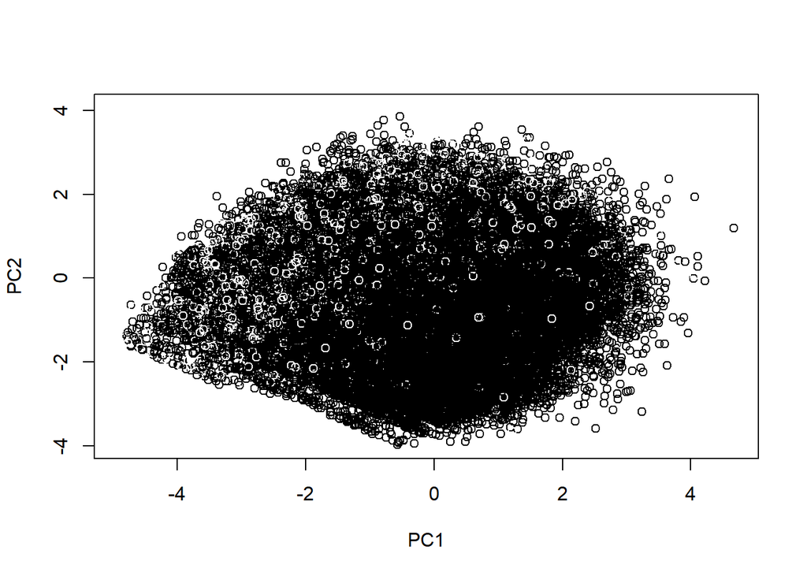

```r
# pull off numeric columns again
input <- mod2train[2:6]
pca <- prcomp(input, scale. = F, center = F)
plot(pca$x[,1:2], col = mod2train$renewal)
```

```r
pcaTrain <- pca$x
pcaTrain <- cbind(pcaTrain, modTrain[7:13])
pcaLR1 <- glm(renewal ~ ., data = pcaTrain, family='binomial')
summary(pcaLR1)
```

```
##
## Call:
## glm(formula = renewal ~ ., family = "binomial", data = pcaTrain)
##
## Deviance Residuals:
##     Min       1Q   Median       3Q      Max
## -3.1819   0.1683   0.2260   0.3345   1.7100
##
## Coefficients:
##               Estimate Std. Error z value Pr(>|z|)
## (Intercept)    3.59958    0.08582  41.943  < 2e-16 ***
## PC1            0.22571    0.02392   9.435  < 2e-16 ***
## PC2           -0.44529    0.02574 -17.298  < 2e-16 ***
## PC3           -0.24447    0.02511  -9.736  < 2e-16 ***
## PC4            0.22085    0.03425   6.448 1.14e-10 ***
## PC5            0.23290    0.03084   7.551 4.31e-14 ***
## allCash       -0.59644    0.10722  -5.563 2.65e-08 ***
## cashBinmed    -0.22286    0.08441  -2.640 0.008286 **
## cashBinhigh   -0.31684    0.09095  -3.484 0.000495 ***
## cashBinwow    -0.31195    0.13739  -2.271 0.023176 *
## everlate      -1.03479    0.03449 -29.999  < 2e-16 ***
## verylate      -1.78263    0.04361 -40.874  < 2e-16 ***
## incomeCatmed   0.12927    0.04413   2.929 0.003398 **
## incomeCathigh  0.33780    0.05012   6.740 1.58e-11 ***
## incomeCatrich  0.42886    0.06487   6.611 3.83e-11 ***
## sourceD       -0.17039    0.05006  -3.404 0.000664 ***
## ---
## Signif. codes:  0 '***' 0.001 '**' 0.01 '*' 0.05 '.' 0.1 ' ' 1
##
## (Dispersion parameter for binomial family taken to be 1)
##
##     Null deviance: 35809  on 76854  degrees of freedom
## Residual deviance: 28609  on 76839  degrees of freedom
## AIC: 28641
##
## Number of Fisher Scoring iterations: 7
```

```r
pcaPred <- predict(pcaLR1, pcaTrain, type = 'resp')
# head(pcaPred)
pcaTrain$pred <- pcaPred
pcaTrain$predBinary <- as.integer(ifelse(pcaTrain$pred >= .9, 1, 0))
pcaROC <- ggplot(pcaTrain, aes(d=renewal, m = pred))+geom_roc()
pcaROC
```

[output not shown]

```r
confusionMatrix(factor(pcaTrain$predBinary), factor(pcaTrain$renewal), pos="1")
```

```
## Confusion Matrix and Statistics
##
##           Reference
## Prediction     0     1
##          0  2695  8374
##          1  2085 63701
##
##                Accuracy : 0.8639
##                  95% CI : (0.8615, 0.8663)
##     No Information Rate : 0.9378
##     P-Value [Acc > NIR] : 1
##
##                   Kappa : 0.2773
##  Mcnemar's Test P-Value : <2e-16
##
##             Sensitivity : 0.8838
##             Specificity : 0.5638
##          Pos Pred Value : 0.9683
##          Neg Pred Value : 0.2435
##              Prevalence : 0.9378
##          Detection Rate : 0.8288
##    Detection Prevalence : 0.8560
##       Balanced Accuracy : 0.7238
##
##        'Positive' Class : 1
##
```

```r
auc4 <- roc(pcaTrain$renewal, pcaPred)
auc4
```

```
##
## Call:
## roc.default(response = pcaTrain$renewal, predictor = pcaPred)
##
## Data: pcaPred in 4780 controls (pcaTrain$renewal 0) < 72075 cases (pcaTrain$renewal 1).
## Area under the curve: 0.8239
```

## Dumb model

sanity check

```r
# colnames(trainCC)
few <- trainCC[c(2,3,17,19,13)]
fewLM <- glm(renewal ~ ., data = few, family = 'binomial')
summary(fewLM)
```

```
##
## Call:
## glm(formula = renewal ~ ., family = "binomial", data = few)
##
## Deviance Residuals:
##     Min       1Q   Median       3Q      Max
## -3.0681   0.1823   0.2234   0.3545   1.1239
##
## Coefficients:
##                                    Estimate Std. Error z value Pr(>|z|)
## (Intercept)                       3.267e+00  7.291e-02  44.809  < 2e-16
## perc_premium_paid_by_cash_credit -2.062e+00  4.603e-02 -44.807  < 2e-16
## age_in_days                       3.282e-05  3.415e-06   9.611  < 2e-16
## incomeCatmed                      9.429e-02  4.119e-02   2.289   0.0221
## incomeCathigh                     3.051e-01  4.433e-02   6.881 5.92e-12
## incomeCatrich                     3.587e-01  4.681e-02   7.663 1.81e-14
## everlate                         -1.329e+00  3.236e-02 -41.080  < 2e-16
##
## (Intercept)                      ***
## perc_premium_paid_by_cash_credit ***
## age_in_days                      ***
## incomeCatmed                     *
## incomeCathigh                    ***
## incomeCatrich                    ***
## everlate                         ***
## ---
## Signif. codes:  0 '***' 0.001 '**' 0.01 '*' 0.05 '.' 0.1 ' ' 1
##
## (Dispersion parameter for binomial family taken to be 1)
##
##     Null deviance: 35809  on 76854  degrees of freedom
## Residual deviance: 30271  on 76848  degrees of freedom
## AIC: 30285
##
## Number of Fisher Scoring iterations: 6
```

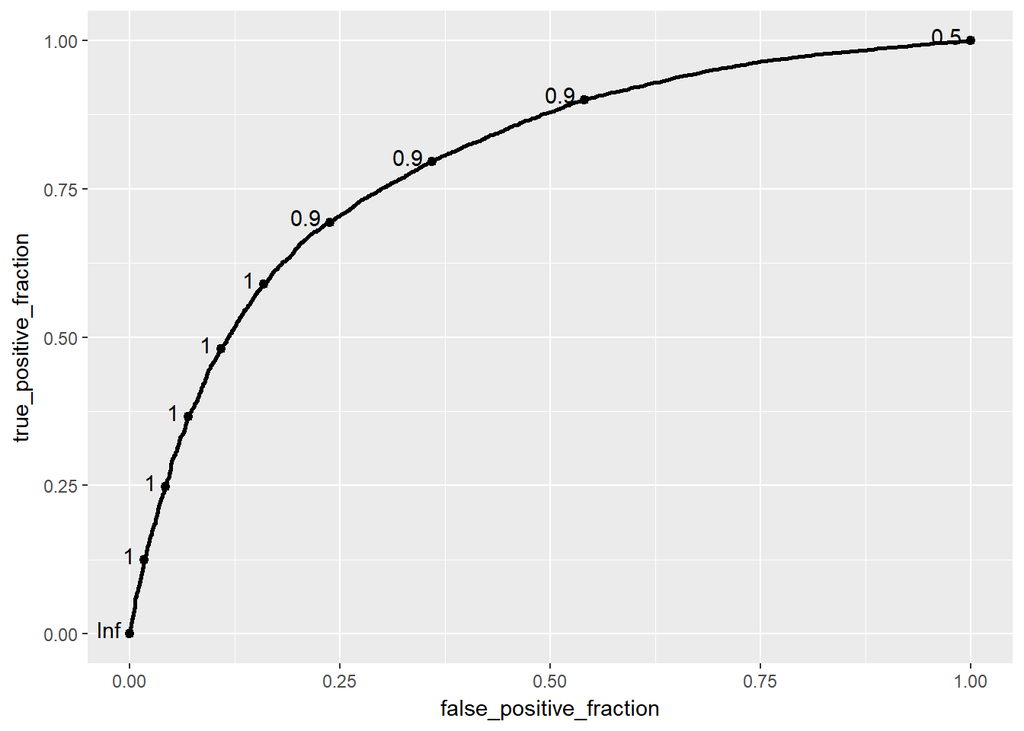

```r
fewPred <- predict(fewLM, few, type = 'resp')
# head(fewPred)
few$pred <- fewPred
few$predBinary <- as.integer(ifelse(few$pred >= .9, 1, 0))
fewROC <- ggplot(few, aes(d=renewal, m = pred))+geom_roc(); fewROC
```

```r
fewAUC <- roc(few$renewal, fewPred); fewAUC
```

```
##
## Call:
## roc.default(response = few$renewal, predictor = fewPred)
##
## Data: fewPred in 4780 controls (few$renewal 0) < 72075 cases (few$renewal 1).
## Area under the curve: 0.7955
```

ok.. sort of confirmed, AUC lower at .79

## Checking on test set

no lables, nothing to check without submitting

lets see how many na’s in test

```r
test <- read.csv('test.csv')
summary(test)
```

```
##        id         perc_premium_paid_by_cash_credit  age_in_days
##  Min.   :     1   Min.   :0.0000                   Min.   : 7671
##  1st Qu.: 28255   1st Qu.:0.0340                   1st Qu.:14972
##  Median : 56488   Median :0.1690                   Median :18623
##  Mean   : 56740   Mean   :0.3145                   Mean   :18824
##  3rd Qu.: 85386   3rd Qu.:0.5400                   3rd Qu.:22636
##  Max.   :114077   Max.   :1.0000                   Max.   :35785
##
##      Income         Count_3.6_months_late Count_6.12_months_late
##  Min.   :   24030   Min.   : 0.0000       Min.   : 0.00000
##  1st Qu.:  106398   1st Qu.: 0.0000       1st Qu.: 0.00000
##  Median :  165070   Median : 0.0000       Median : 0.00000
##  Mean   :  202820   Mean   : 0.2387       Mean   : 0.08072
##  3rd Qu.:  250020   3rd Qu.: 0.0000       3rd Qu.: 0.00000
##  Max.   :21914550   Max.   :12.0000       Max.   :10.00000
##                     NA's   :31            NA's   :31
##  Count_more_than_12_months_late application_underwriting_score
##  Min.   :0.00000                Min.   :91.90
##  1st Qu.:0.00000                1st Qu.:98.80
##  Median :0.00000                Median :99.21
##  Mean   :0.05811                Mean   :99.06
##  3rd Qu.:0.00000                3rd Qu.:99.53
##  Max.   :7.00000                Max.   :99.89
##  NA's   :31                     NA's   :1323
##  no_of_premiums_paid sourcing_channel residence_area_type    premium
##  Min.   : 2.00       A:18672          Rural:13616         Min.   : 1200
##  1st Qu.: 7.00       B: 6923          Urban:20608         1st Qu.: 5400
##  Median :10.00       C: 5146                              Median : 7500
##  Mean   :10.89       D: 3222                              Mean   :10835
##  3rd Qu.:14.00       E:  261                              3rd Qu.:13800
##  Max.   :59.00                                            Max.   :60000
##
```

going to need some kind of imputation, or figure out what NA means